# DATA 606 Final Project

Josh Iden

## Abstract

This project looks at responses from a FiveThirtyEight.com sponsored survey conducted between Sept. 15-25 2020 amongst non-voters to questions regarding their attitudes about elections and whether there is a relationship between education level and voter attitudes based on those responses. Of the 33 questions posed in the survey, we have selected the 3 questions that focus specifically on attitudes towards voting. We then determine if a logistic regression model is appropriate to estimate the relationship between education level and the survey response attitudes towards voting and if a response score is able to predict a college degree and posit a null hypothesis that there is no relationship between the responses and having a college degree.

## Part 1 - Introduction

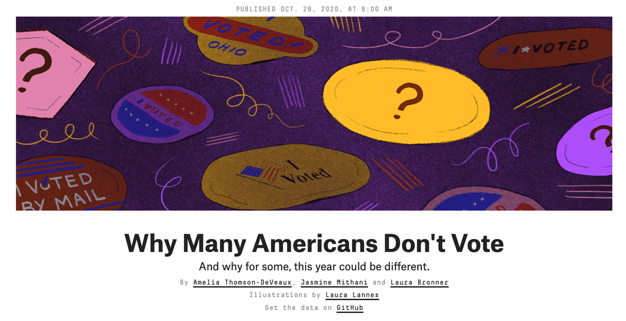

This project focuses on the question “Is education level related to voter attitudes amongst non-voters?” using data collected for the FiveThirtyEight.com report [“Why Many Americans Don’t Vote”](https://projects.fivethirtyeight.com/non-voters-poll-2020-election/)

## Part 2 - Data

- 5,836 respondents
- Collected by Ipsos for FiveThirtyEight.
- The study is Observational, relying on data taken from a random sample.
- https://github.com/fivethirtyeight/data/blob/master/non-voters/README.md)

Let’s take a look at the data.

```r
# loading dataset
url = "https://raw.githubusercontent.com/fivethirtyeight/data/master/non-voters/nonvoters_data.csv"
df = read.csv(url)
dim(df)
```

```
## [1] 5836  119
```

The dataset contains 5,836 observations across 119 columns (questions). For the purpose of this analysis, we will subset the data down to the desired data: Education, and Questions 5, 16, and 20.

These questions are as follows:

**Q5: Does it matter who wins elections? 1 = Yes, 2 = No**

**Q16: In general, how easy or difficult is it to vote in elections? 1 = Very Easy, 4 = Very Difficult**

**Q20: Are you currently registered to vote? 1 = Yes, 2 = No**

### Subsetting the Data

```r
cols = c("educ","Q5","Q16","Q20")
df.sub = df[cols]
kable(head(df.sub))
```

| educ | Q5 | Q16 | Q20 |
| --- | --- | --- | --- |
| College | 1 | 1 | 1 |
| College | 1 | 2 | 1 |
| College | 1 | 1 | 1 |
| Some college | 1 | 4 | 1 |
| High school or less | 1 | 1 | 1 |
| High school or less | 2 | -1 | 2 |

### Summary Statistics

Let’s take a look at the summary statistics:

```r
summary(df.sub)
```

```
##      educ                 Q5             Q16             Q20
##  Length:5836        Min.   :-1.00   Min.   :-1.00   Min.   :-1.000
##  Class :character   1st Qu.: 1.00   1st Qu.: 1.00   1st Qu.: 1.000
##  Mode  :character   Median : 1.00   Median : 1.00   Median : 1.000
##                     Mean   : 1.16   Mean   : 1.62   Mean   : 1.076
##                     3rd Qu.: 1.00   3rd Qu.: 2.00   3rd Qu.: 1.000
##                     Max.   : 2.00   Max.   : 4.00   Max.   : 2.000
```

```r
sum(is.na(df.sub))
```

```
## [1] 0
```

### Replacing Negative Values

The first thing that pops out are the minimum values of -1, since the minimum response value is 1. Let’s see how many of those there are.

```r
df.sub |> filter(Q5 == -1 | Q16 == -1 | Q20 == -1) |> count()
```

```
##    n
## 1 82
```

There are 82 rows with -1 entries.

```r
df.sub |> filter(Q5 == -1 | Q16 == -1 | Q20 == -1) |> head()
```

```
##                  educ Q5 Q16 Q20
## 1 High school or less  2  -1   2
## 2        Some college  1  -1   2
## 3        Some college  1  -1   1
## 4 High school or less  1   2  -1
## 5 High school or less -1  -1  -1
## 6 High school or less  2   2  -1
```

We can see that these negative values do not otherwise affect other responses. This is likely a data entry error. To rectify this, I will impute a value of 1 for every -1 value.

```r
df.sub <- df.sub |>
  mutate(Q5 = as.numeric(abs(Q5)),
            Q16 = as.numeric(abs(Q16)),
            Q20 = as.numeric(abs(Q20)))

summary(df.sub)
```

```
##      educ                 Q5            Q16            Q20
##  Length:5836        Min.   :1.00   Min.   :1.00   Min.   :1.000
##  Class :character   1st Qu.:1.00   1st Qu.:1.00   1st Qu.:1.000
##  Mode  :character   Median :1.00   Median :1.00   Median :1.000
##                     Mean   :1.17   Mean   :1.64   Mean   :1.083
##                     3rd Qu.:1.00   3rd Qu.:2.00   3rd Qu.:1.000
##                     Max.   :2.00   Max.   :4.00   Max.   :2.000
```

We can see this didn’t significantly affect the summary statistics.

## Part 3 - Exploratory data analysis

### Distribution of Education

Let’s take a look at the distribution of education.

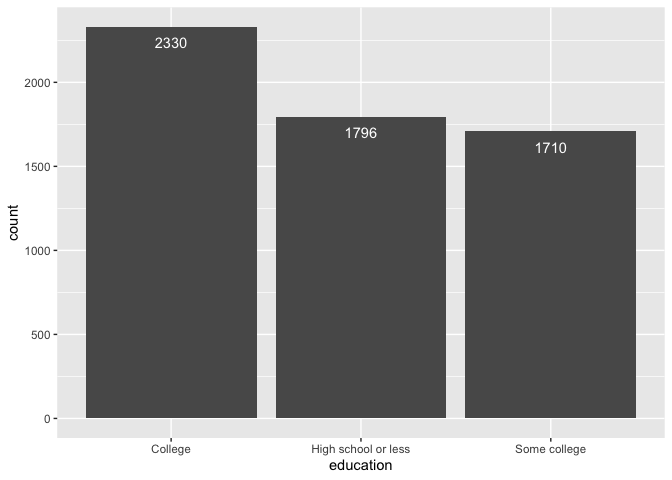

```r
ggplot(df.sub, aes(x=educ)) +
  geom_bar() +
  geom_text(aes(label = after_stat(count)),
            stat="count", vjust=2,
            color="white") +
  labs(x = "education")
```

### Education Frequency Table

```r
kable(prop.table(table(df.sub$educ)), col.names=c("Level","Freq"))
```

| Level | Freq |
| --- | --- |
| College | 0.3992461 |
| High school or less | 0.3077450 |
| Some college | 0.2930089 |

We can see from the survey responses, college graduates accounted for just under 40% of non-voters amongst respondents, while those hadn’t completed college accounted for just over 60% of respondents.

### Average Answer by Education Level

Taking a look at average answer by education level,

```r
df.sub |>
  group_by(educ) |>
  summarize(Q5 = mean(Q5),
            Q16 = mean(Q16),
            Q20 = mean(Q20))
```

```
## # A tibble: 3 × 4
##   educ                   Q5   Q16   Q20
##   <chr>               <dbl> <dbl> <dbl>
## 1 College              1.13  1.63  1.02
## 2 High school or less  1.22  1.68  1.17
## 3 Some college         1.17  1.61  1.07
```

We can see that responders with an education level of “High School or less” has the highest response scores – with higher scores representing more negative attitudes towards voting. Somewhat surprisingly, respondents with “some college” tend to view the difficulty involved with voting (Q16) more favorably than the other groups.

### Transforming the Data

As question 16 is rated on a scale of 1-4, 1 being “very easy”, 2 being “easy”, 3 = “difficult”, 4 = “very difficult”, we dichotomize the scores to 1 and 2 in order to visualize and model the relationship. We also dichotomize the education variable, with “yes” representing “has a college degree”, and “no” representing “does not have a college degree”.

```r
college <- df.sub |>
  mutate(Q16 = as.numeric(ifelse(Q16 < 3, 1, 2)),
         Q5 = factor(Q5),
         Q16 = factor(Q16),
         Q20 = factor(Q20),
         college = factor(ifelse(educ == "College", "yes","no"))) |>
  select(5, 2:4)
kable(head(college))
```

| college | Q5 | Q16 | Q20 |
| --- | --- | --- | --- |
| yes | 1 | 1 | 1 |
| yes | 1 | 1 | 1 |
| yes | 1 | 1 | 1 |
| no | 1 | 2 | 1 |
| no | 1 | 1 | 1 |
| no | 2 | 1 | 2 |

Let’s take a look at the average answer by education now,

```r
college |>
  group_by(college) |>
  summarize(Q5 = mean(as.numeric(Q5)),
            Q16 = mean(as.numeric(Q16)),
            Q20 = mean(as.numeric(Q20)))
```

```
## # A tibble: 2 × 4
##   college    Q5   Q16   Q20
##   <fct>   <dbl> <dbl> <dbl>
## 1 no       1.20  1.15  1.12
## 2 yes      1.13  1.15  1.02
```

We can see there’s almost no difference in the answers for Question 16.

Now, let’s take a look at the distribution of responses by education level.

### Distribution of Ratings by Dichotomized Education

Let’s look at a scatter plot of the data,

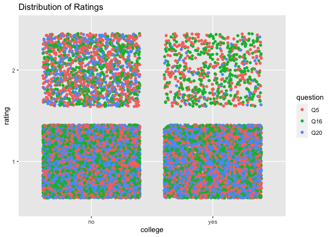

```r
college |>
  pivot_longer(cols = c(2:4), names_to = "question", values_to = "rating") |>
  mutate(question = factor(question, levels=c("Q5","Q16","Q20"))) |>
  ggplot(aes(x=college, y=rating, color=question)) +
  geom_jitter() +
  ylim("1","2") +
  labs(title = "Distribution of Ratings")
```

We can see when we try to visualize this data as a scatterplot, the binomial versus categorical variables do not provide much insight into a correlation and there’s certainly no linear relationship.

So instead we model the data as a barplot. Here we can see that the proportions of responses for college graduates versus non college graduates for questions 5 & 20 is more apparent than for question 16, which looks like a relatively comparable proportion.

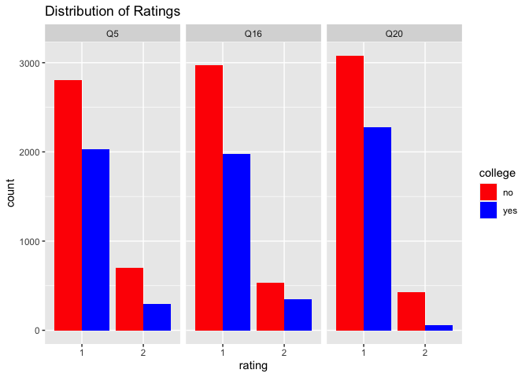

```r
college |>
  pivot_longer(cols = c(2:4), names_to = "question", values_to = "rating") |>
  ggplot(aes(x=rating, fill=college)) +
  facet_grid(~factor(question, levels=c('Q5','Q16','Q20'))) +
  geom_bar(position = "dodge") +
  labs(title = "Distribution of Ratings") +
  xlim("1","2") +
  scale_fill_manual(values=c("red","blue"))
```

We can see by the binomial ratings that a linear regression model would not be appropriate for this data. A logistic model, however, will allow us to observe whether a relationship exists.

## Part 4 - Inference

### Examining the Variables

The **dependent varibale** for this analysis is education level, yes = has college degree, no = no college degree.

The **independent variables** are the binomial question scores.

Let’s look at a frequency table for college degrees:

```r
kable(prop.table(table(college$college)), col.names=c("Level","Freq"))
```

| Level | Freq |
| --- | --- |
| no | 0.6007539 |
| yes | 0.3992461 |

Split is about 60/40.

Now let’s estimate the population proportion to see if this holds.

```r
college |>
  specify(response = college, success = "yes") |>
  generate(reps = 1000, type = "bootstrap") |>
  calculate(stat = "prop") |>
  get_ci(level = 0.95)
```

```
## # A tibble: 1 × 2
##   lower_ci upper_ci
##      <dbl>    <dbl>
## 1    0.387    0.412
```

Let’s examine the relationship between college degree and response scores.

### Multiple Logistic Regression Model

First, let’s see if there’s a relationship between the variables.

We build the logistic model using the glm() function and passing “binomial” into the family argument.

```r
college_mod.full <- glm(college ~ ., data = college, family=binomial(link="logit"))
summary(college_mod.full)
```

```
##
## Call:
## glm(formula = college ~ ., family = binomial(link = "logit"),
##     data = college)
##
## Deviance Residuals:
##     Min       1Q   Median       3Q      Max
## -1.0979  -1.0629  -0.9465   1.2964   2.1364
##
## Coefficients:
##             Estimate Std. Error z value Pr(>|z|)
## (Intercept) -0.27547    0.03145  -8.758  < 2e-16 ***
## Q52         -0.29528    0.07844  -3.764 0.000167 ***
## Q162         0.08559    0.07688   1.113 0.265586
## Q202        -1.60368    0.14532 -11.036  < 2e-16 ***
## ---
## Signif. codes:  0 '***' 0.001 '**' 0.01 '*' 0.05 '.' 0.1 ' ' 1
##
## (Dispersion parameter for binomial family taken to be 1)
##
##     Null deviance: 7851.8  on 5835  degrees of freedom
## Residual deviance: 7634.7  on 5832  degrees of freedom
## AIC: 7642.7
##
## Number of Fisher Scoring iterations: 4
```

We can see that question 16 (perceived ease of voting) does not have significance in this model, so using backwards stepwise regression, we remove the variable from the model and re-run.

```r
college_mod.v2 <- glm(college ~ Q5 + Q20, data = college, family=binomial(link="logit"))
summary(college_mod.v2)
```

```
##
## Call:
## glm(formula = college ~ Q5 + Q20, family = binomial(link = "logit"),
##     data = college)
##
## Deviance Residuals:
##     Min       1Q   Median       3Q      Max
## -1.0677  -1.0677  -0.9519   1.2912   2.1263
##
## Coefficients:
##             Estimate Std. Error z value Pr(>|z|)
## (Intercept) -0.26364    0.02958  -8.912  < 2e-16 ***
## Q52         -0.29310    0.07840  -3.738 0.000185 ***
## Q202        -1.59365    0.14500 -10.991  < 2e-16 ***
## ---
## Signif. codes:  0 '***' 0.001 '**' 0.01 '*' 0.05 '.' 0.1 ' ' 1
##
## (Dispersion parameter for binomial family taken to be 1)
##
##     Null deviance: 7851.8  on 5835  degrees of freedom
## Residual deviance: 7635.9  on 5833  degrees of freedom
## AIC: 7641.9
##
## Number of Fisher Scoring iterations: 4
```

We see both questions maintain similar significance to the full model.

So we see there is significance, but can the model predict the probability of a college degree based on the response score?

### Making Predictions

First we split the data into training and test sets:

```r
set.seed(123)
indices <- sample.split(Y = college$college, SplitRatio=0.8)
college.train <- college[indices,]
college.test<- college[!indices,]
```

Next, we make predictions using the testing set. First we build a model using the training set.

```r
training.mod <- glm(college ~ Q5 + Q20, data=college.train, family=binomial(link="logit"))
```

We make predictions for the testing set using the training model, passing “response” into the type argument, and estimate the probability the test model is able to predict a college degree. We know from our earlier frequency table that the proportion of college degrees is about 40%, hence the probability of observing a college degree is 40%, we set the threshold for predictions to 0.4.

```r
preds <- predict(training.mod, newdata = college.test, type = "response")
predicted <- table(college_degree = college.test$college, predicted_value = preds>0.4 )
my_mat = as.matrix(predicted)
my_mat
```

```
##               predicted_value
## college_degree FALSE TRUE
##            no    181  520
##            yes    65  401
```

Given accuracy = $TP + TN / TP + TN + FP + FN = $

```r
TN <- my_mat[1] # true negative (no/false)
FP <- my_mat[2] # false positive (yes/false)
FN <- my_mat[3] # false negative (no/true)
TP <- my_mat[4] # true positive (yes/true)

accuracy = (TP + TN)/(TP + TN + FP + FN)
accuracy
```

```
## [1] 0.4987147
```

We see the model only predicts with about 50% accuracy.

Using the ROC package, we can plot the trade off between sensitivity (True Positive) and specificity (True Negative):

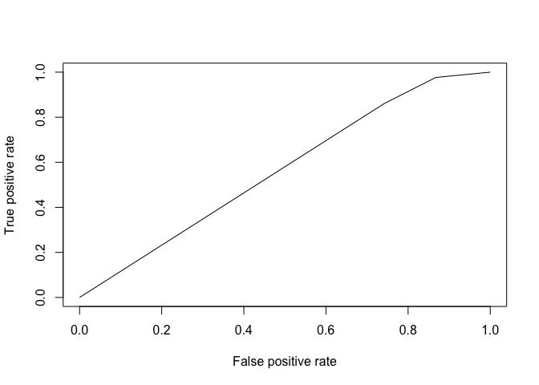

```r
p = prediction(preds, college.test$college)
prf <-performance(p, measure ="tpr", x.measure ="fpr")
plot(prf)
```

The nearly straight line confirms the model offers nearly no predictive value.

Lastly, let’s take a look at the Area Under the Curve (AUC)

```r
auc <- performance(p, measure = "auc")
auc <- auc@y.values[[1]]

auc
```

```
## [1] 0.5655685
```

AUC measures separability. 0 = reciprocation, 1 = separability. 0.5 = no class separation capacity.

## References

https://godatadrive.com/blog/basic-guide-to-test-assumptions-of-linear-regression-in-r https://feliperego.github.io/blog/2015/10/23/Interpreting-Model-Output-In-R https://online.stat.psu.edu/stat462/node/116/ https://medium.com/pew-research-center-decoded/a-short-intro-to-linear-regression-analysis-using-survey-data-ff39468f8afb https://www.displayr.com/what-is-a-roc-curve-how-to-interpret-it/ https://towardsdatascience.com/understanding-auc-roc-curve-68b2303cc9c5